# Gender and Classification Trends in MoMA Artworks

Alejandra Chavarria

2025-06-13

# 1 Introduction

The Museum of Modern Art (MoMA) collection contains a wide array of artworks throughout history. Our group explored how gender is represented in the MoMA collection, with a focus on how classifications (such as painting, sculpture, etc.) vary by artist gender. Our research question is as follows: Is there a correlation between an artist’s gender and the types of media or themes they work in, as represented in the collection between 1841- 1928?

Previous studies and critiques have pointed to a lack of representation of women and non-binary artists in museum collections. By examining the MoMA dataset, this project aims to outline and see the disparity and explore whether certain classifications are more inclusive than others.

The primary objective of this study is to examine the relationship between artist gender and the type of artwork classifications represented in the MoMA collection. This topic is important because it illustrates just how prevalent artwork is and how influential museums like MoMA are in picking artists. What we display to the public can shape societal norms, especially around gender.

We feel as if anyone within the art world should care about these results, especially artists and those who work with the art. The more people who understand the gendered patterns and issues within the industry, the more we can create change to combat against the inequalities and create more inclusive practices for all.

# 2 Data and Methods

The data was accessed via [MoMA’s GitHub archive](https://github.com/MuseumofModernArt/collection).

To analyze gender representation across artwork types, we grouped the dataset by `Gender` and `Classification` using `dplyr`. We then calculated the number of artworks in each category and used `ggplot2` to create bar plots that compare classification frequency across genders. These descriptive and visual methods were chosen to clearly display proportional differences in representation across categories, making trends and disparities easier to interpret.

Below is the code used to import and prepare the data:

```r
artworks <- read_csv("Artworks copy.csv") %>%
  filter(!is.na(Gender)) %>%
  mutate(
    Gender = as.factor(Gender),
    Classification = as.factor(Classification)
  )
```

```r
Momaart_df <- read_csv("Artworks copy.csv")
Momaartist_df <- read_csv("Artists copy.csv")

moma <- left_join(Momaart_df, Momaartist_df, by = c("Artist" = "DisplayName"))

moma_years <- moma %>%
  mutate(Year = as.numeric(str_extract(Date, "[0-9]{4}"))) %>%
  filter(!is.na(Year))

moma_early <- moma_years %>%
  filter(
    Year >= 1841, Year <= 1928,
    !is.na(Gender.y),
    !is.na(Classification),
    str_to_lower(Gender.y) %in% c("male", "female")
  ) %>%
  slice_sample(n = 200)
```

# 3 Results

This section presents the summarized data and visualizations of how artwork classifications differ by gender. We begin with a summary table of counts by `Gender` and `Classification`, followed by a bar graph that shows these differences visually.

```r
classification_gender <- moma_early %>%
  rename(Gender = Gender.y) %>%
  count(Gender, Classification, sort = TRUE)

knitr::kable(head(classification_gender, 10))
```

| Gender | Classification | n |
| --- | --- | --- |
| male | Photograph | 82 |
| male | Illustrated Book | 41 |
| male | Print | 21 |
| male | Design | 11 |
| male | Mies van der Rohe Archive | 11 |
| male | Drawing | 10 |
| male | Frank Lloyd Wright Archive | 5 |
| female | Illustrated Book | 4 |
| female | Photograph | 4 |
| male | Painting | 4 |

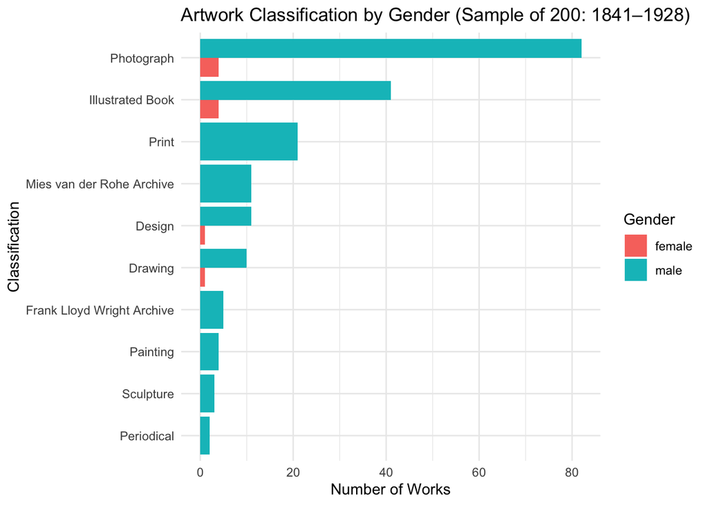

```r
classification_gender <- moma_early %>%
  rename(Gender = Gender.y) %>%
  count(Gender, Classification, sort = TRUE)

ggplot(classification_gender, aes(x = reorder(Classification, n), y = n, fill = Gender)) +
  geom_bar(stat = "identity", position = "dodge") +
  coord_flip() +
  labs(
    title = "Artwork Classification by Gender (Sample of 200: 1841–1928)",
    x = "Classification",
    y = "Number of Works"
  ) +
  theme_minimal()
```

This bar chart visualizes how artwork classification frequencies differ between male and female artists. While both genders are represented across multiple categories, male artists are over represented in nearly all of them.

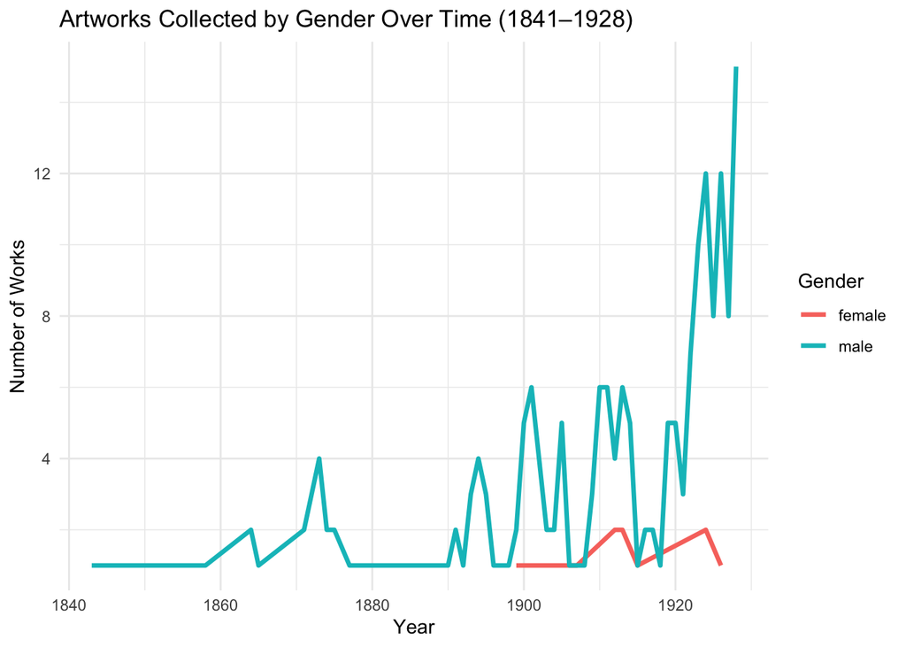

```r
gender_by_year <- moma_early %>%
  count(Year, Gender.y)

ggplot(gender_by_year, aes(x = Year, y = n, color = Gender.y)) +
  geom_line(linewidth = 1.2) +
  labs(
    title = "Artworks Collected by Gender Over Time (1841–1928)",
    x = "Year",
    y = "Number of Works",
    color = "Gender"
  ) +
  theme_minimal()
```

# 4 Discussion

These findings reinforce longstanding critiques about the historical underrepresentation of women in institutional art spaces. This reflects not only limited opportunities for women artists, but also a biased idea of what counted as “serious” or collectible art during this time period.

Our graphs suggest that this disparity wasn’t just about the number of artworks — it affected which artists were seen as important, and whose work was remembered and displayed in museums. It’s a strong reminder that gender has played a significant role in shaping the art world, and that these patterns still matter today. These trends deserve attention. For museum professionals, educators, and artists, this kind of analysis can inform more equitable practices, from acquisitions to exhibitions, that promote broader gender representation in the cultural record.